# World Heritage Sites on Wikipedia: Inscription Controversies in a Context of Constrained Agency for Cultural Heritage Activism

Ben Marwick

Prema Smith

22 May, 2020

Abstract

UNESCO World Heritage sites are places of outstanding significance, and often key sources of information that influence how people interact with the past today. The process of inscription on the UNESCO list is complicated and intersects with political and commercial controversies. But how well are these controversies known to the public? Wikipedia pages on these sites offer a unique dataset for insights into public understanding of heritage controversies. The unique technicity of Wikipedia, with its bot ecosystem and editing mechanics, shapes how knowledge about cultural heritage is constructed, and how controversies are negotiated and communicated. In this article we investigate the patterns of production, consumption and spatial and temporal distributions of Wikipedia pages for World Heritage cultural sites. We find that Wikipedia provides a distinctive context for investigating how people experience and relate to the past in the present. The agency of participants is highly constrained, but distinctive, behind-the-scenes expressions of cultural heritage activism are evident. Concerns about state-like actors, violence and destruction, deal-making, etc. in the World Heritage inscription process are poorly represented on Wikipedia’s World Heritage pages, instead hyper-local, and process issues dominate controversies on Wikipedia. We will consider how this kind of research, drawing on big data and data science methods, adds new dimensions to the debate on heritage controversies, especially its unique contributions, and also its limitations.

# 1 Introduction

Heritage is the processes and outcomes of people engaging with elements of the past – material and immaterial – and attributing social and cultural meanings to them in the present (Smith 2006; Harrison 2013). These are important to understand because they shape peoples’ identities and influence how they think and behave towards other people. Digital heritage are these engagements that are enabled by the Internet (Bonacchi and Krzyzanska, 2019), leaving traces that can be identified and quantified using data science methods. Digital heritage studies represent a major turn from traditional heritage studies, characterized by post-modernism (Kristiansen, 2014), critical theory, and qualitative methods, towards novel ontologies, data-intensive ethnographies, and a new role for heritage scholars as data scientists. Bonacchi et al. (2019; 2018) have sketched out the new digital heritage research program with their combination of data-intensive and qualitative investigations of 1.4m Facebook posts in Brexit-related community groups. They found recurring parallels – both pro- and anti-Brexit – made by Facebook users between the European Union, the Roman Empire and “barbarians” as they use heritage to support their political activism. They demonstrate the potential for understanding public perceptions and experiences of the past in contemporary society using big data obtained from social media. In this paper we extend the digital heritage research program in two important new directions. First, we introduce Wikipedia as an example of an online peer production community where people engage with elements of the past in measurable ways. Second, present a case study using data science methods to investigate the ways people create and consume Wikipedia articles on cultural sites inscribed on the UNESCO World Heritage List (hereafter CS-WHL).

While social media is a vast and diverse online space that we are only just beginning to explore how people engage with the past, there are other contexts of online interactions where heritage is practiced in distinctive, if poorly understood, ways. We can contrast social media, with its fundamental elements of identity, conversations, sharing, presence, relationships, reputation, and groups (Kietzmann et al., 2011), with peer production communities, where online users participate in the collaborative, asynchronous creation, sharing, promoting, and classification of content in highly structured and goal-directed ways (Wilkinson, 2008). Online peer production communities are comparable to more traditions kinds of voluntary associations where groups set and execute goals, with explicitly democratic organizational ideals. While the ideals of many online peer production communities emphasize non-hierarchical and non-bureaucratic organization, analysis of large amounts of user activity indicates that most of these communities are actually undemocratic and noninclusive, functioning as entrenched oligarchies (Shaw and Hill, 2014). This emphasis on governance and management of collective action is a key detail that distinguishes online communities on social media from online communities on peer production projects. It follows that user interactions in the process of generating context in online peer production communities includes technological and social mechanisms that enact the community’s governance policies, for example, limiting a user’s activity according to their status in the community’s hierarchy, or managing conflict with highly structured procedures. These distinctive organizational and technical qualities of online peer production communities make them an intriguing novel context of heritage production to study digital traces of human activity resulting from engagement with the past

## 1.1 Wikipedia as a Context of Heritage Production

Here we present a study of how people engage with elements of the past in one of the largest and long-lived online peer production communities, Wikipedia. This is a highly influential, with 11 billion page views per month (https://stats.wikimedia.org/#/en.wikipedia.org), and well-known online encyclopedia that anyone can edit. Although anyone can edit, most internet users do not, and the characteristics of people who do edit are important to understand to identify biases in the encyclopedia’s content. In a survey of 1,512 American adults, Shaw and Hargittai (2018) found that majority of internet users (96.5%) had heard of Wikipedia, and 82.5% of those said that they had ever visited the site. Just over two thirds (67.3%) knew that Wikipedia can be edited, but only 8.2% of the full sample had ever edited any page. Factors that strongly predict if a user has ever edited Wikipedia include their gender (male), age (younger), education level (has BA), Internet use frequency (higher) and Internet use skills (higher). Hill and Shaw (2013) a similarly found that among U.S. adult contributors to the English-language edition of Wikipedia, at least 75% are male. While gender disparities have been documented throughout Wikipedia (Adams and Brückner, 2015; Ford and Wajcman, 2017), there are also geographical disparities. Johnson et al. (2016) examined 218,709 English geotagged articles about places in the contiguous United States and 46,124 Chinese geotagged articles about places in China to investigate differences in articles about urban and rural places. They found that articles about rural areas have systematically lower quality, are less likely to have been produced by contributors who focus on the local area, and are more likely to have been generated by bots (automated software agents). These studies indicate that inequalities on a range of variables mean that participation in online peer production communities often exacerbates existing patterns of social exclusion.

An additional consideration for understanding participation in online peer production communities are the technical schemas of the software that Wikipedia runs on, MediaWiki. This is a complex toolkit that enables participation in Wikipedia in highly structured ways. On one hand, these structured behaviours produce structured datasets that are well suited to data science methods for efficient computational analysis of large numbers Wikipedia articles. On the other hand, they constrain and limit the agency of the user, canalizing their behaviour into a small number of possible actions and acceptable modes of discourse and engagement with other users (Iba et al., 2010). While Wikipedia has elements that are ubiquitous on the Internet, such as links on articles that take the user to other articles or other pages on the Internet, it also has several less common elements that contribute to its unique technicity, resulting in very specific types of relationships between human users and the technical elements of the Wikipedia project (Niederer and Van Dijck, 2010). For example, every edit to an article is tracked in a publicly accessible version control system attached to that article. This exposes the article creation process in highly granular detail; for any given article, we can see how many editors contributed, the size of their edits and their distribution over time, among other things (Priedhorsky et al., 2007). Wikipedia has a special category of edit called the ‘revert’ which allows a user to restore an article to an earlier state to remove recent vandalism (such as the addition of irrelevant or offensive material). This special revert action, combined with a ‘talk’ page attached to each encyclopedia article for threaded discussion among editors, allows us to detect and study the dynamics of conflicts arising from the creation and editing of articles (Suh et al., 2007). For example, a high proportion of ‘revert’ type edits, and a high word count on the talk page can indicate the controversiality of an article (Yasseri et al., 2012).

Table 1.1: Summary of Wikipedia bot types and functions, from Zheng et al. (2019)

| Role | Function | Example |
| --- | --- | --- |
| Generator | Generate article pages based on predefined templates. | Rambot, RussBot |
| Fixer | Fix errors in article pages in order to keep the information neat and correct. | CmdrObot, Yobot |
| Connector | Connect Wikipedia with other sites and databases | KasparBot |
| Tagger | Tag articles with different templates and categories | AnomieBot, Smackbot, Cydebot |
| Clerk | A variety of tasks including updating statistical information, documenting user status, updating maintenance pages | AnomieBot, Smackbot |
| Archiver | Archive closed discussions and maintain the archived content by assigning an index and sorting them alphabetically | AnomieBot, Cyberbot_I |
| Protector | Detect and regulate destructive behaviors | ClueBot NG |
| Advisor | Provide editors with suggestions about articles that they might want to contribute to. | SuggestBot |
| Notifier | Deliver messages to editors. | NoomBot |

## 1.2 UNESCO World Heritage Cultural Sites as foci of Conflict

We investigate how the unique technicity of Wikipedia shapes interactions between people and the past with a case study on the processes of constructing knowledge about cultural sites inscribed on the WHL. We chose the CS-WHL as a bounded set of cultural heritage elements with several characteristics that make it of general interest. It has a global geographic distribution, broad public interest at local and international scales, in both online and face-to-face communities; a wide temporal distribution in both the age of the cultural sites, the ages of inscription on the WHL, and the ages of their appearance on Wikipedia; and finally many CS-WHL have a high intensity of cultural and political discussions that surround events affecting these sites, such as their inscription on the WHL. These qualities make it an ideal data set as an entry point for case studies of digital heritage in online peer production communities, where activities are typically goal-driven (e.g. ‘write quality articles’) compared to social media activity where user activities are more often event-driven (e.g. ‘share reactions to Brexit’).

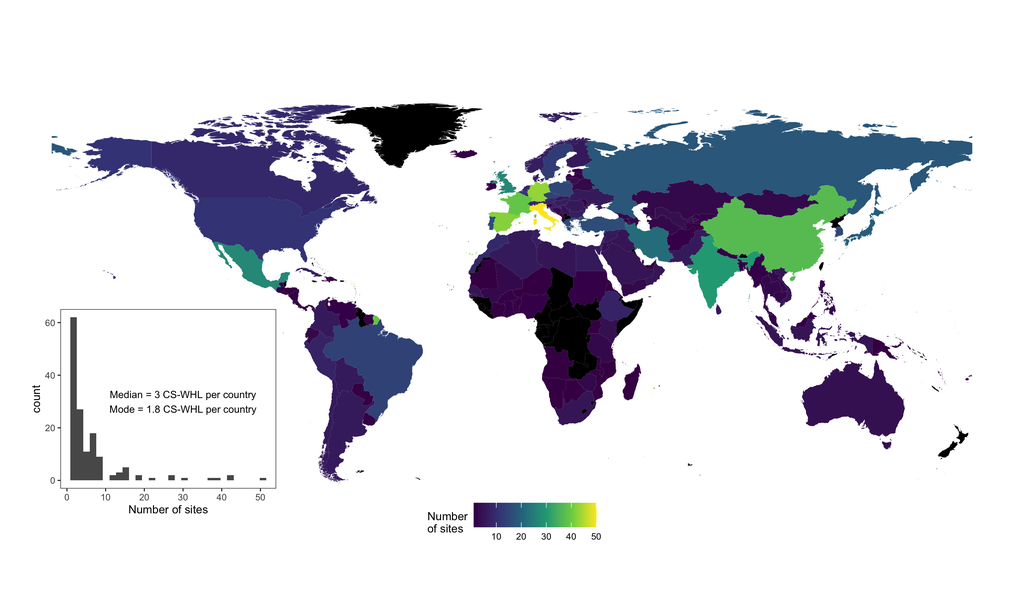

Figure 1.1: Cultural Sites on the UNESCO World Heritage List. Black indicates countries with no sites. Inset shows the distribution of sites per country. Map data from naturalearthdata.com

UNESCO was established in 1945, shortly after the end of the Second World War, for the purpose of helping to rebuild after the war, and preserve peace by promoting the international exchange of ideas. In 1975 the UNESCO-drafted “Convention Concerning the Protection of the World Cultural and Natural Heritage” came into force and established the World Heritage List (WHL) to protect natural and cultural sites and landscapes around the world that have outstanding universal value. Currently there are 869 cultural properties on the UNESCO WHL, with the first sites inscribed in 1978. On average, most countries have 2-3 sites, with most sites located in Italy and western Europe, and several countries having no sites at all, for example, several central African countries, Taiwan, and New Zealand (Figure 1.1).

In her institutional ethnography of UNESCO’s role in protecting world heritage, Meskell (2018) argues that WHL is less about preserving heritage than about political and economic transactions between states and state-like actors. Sites that are listed, or candidates for listing, are often foci of disputes and agreements about territory, sovereignty, and security, as well as international corporate activity (Meskell, 2018). This is because the process of selecting of sites to be inscribed on the WHL has become politicized and driven by countries’ political influence and national strategic interests (Bertacchini et al., 2016). For example, the members of the World Heritage Committee are mostly career diplomats rather than heritage specialists, indicating that the processes and decisions of this committee may be motivated more by political trade-offs than by heritage expertise and judgment (Von Droste, 2011).